# Effects of the FDI on the Economic Growth of Uganda Time series Evidence from 1960 to 2020

- - FDI stock (look at this a stock of FDI belonging to Uganda proxied with net FDI)
- - FDI Inflow
- - FDI Transactions (proxying it using REER)
- - FDI other Changes (Proxying it using net Foreign Assets)
- - GDP of Uganda (This is Yearly)

The time period for analysis is 1960 to 2020, with this raw data having missing values we need to correct for the missing values statistically.

Then raw data is in USD and Net foreign assets is in LCUs (local currency Units) which is converted to USD to make it uniform

The data is cleaned and missing values replaced and the transformation is done in Excel to produce the dataset used in further analysis here

- - Excel work book is [here](https://github.com/michaelgobz/Final-Research-Project-/blob/main/data.xlsx)

**Brief About the Data in Excel File** A little detail about the variables contained here

- - FDI stock (millions of current USD)
- - FDI Inflow (millions of current USD)
- - REER (Real Effective Exchange Rate)[millions of current USD]
- - Excess of NFA (millions of current USD )
- - GDP of Uganda (millions of current USD)

The workbook has 6 sheets where sheet 1 is the raw data obtained from the World Bank. the next 4 sheets include a series of data cleaning and filling in missing values by interpolation, and using the HP filter and try to approximate the values of the missing values. this was necessary for further analysis

Sheet 6 of the workbook contains the final cleaned data ready for further analysis.

**Setting The Analysis Environment**

Setup the packages required for analysis and load them requires the Rtools to build some of the packages download the binaries from here this is only for local setup [Rtools](https://cran.r-project.org/bin/windows/Rtools/rtools42/rtools.html)

**Install the packages**

```r
install.packages("AER")
install.packages("dynlm")
install.packages("forecast")
install.packages("readxl")
install.packages("stargazer")
install.packages("scales")
install.packages("quantmod")
install.packages("urca")
```

**Load Installed Packages**

```r
library(AER)
library(dynlm)
library(forecast)
library(readxl)
library(stargazer)
library(scales)
library(quantmod)
library(urca)
library(stats)
```

**Load the data in from Excel**

```r
dataset <- read_xlsx("./data.xlsx",sheet = 6 )
View(dataset)
```

**Helper functions for Transformations** - - BIC function - - AIC function - - quants growth series generator

```r
# compute BIC for AR model objects of class 'dynlm'
BIC <- function(model) {
  ssr <- sum(model$residualsˆ2)
  t <- length(model$residuals)
  npar <- length(model$coef)
  return(
    round(c("p" = npar - 1,
      "BIC" = log(ssr/t) + (npar + 1) * log(t)/t,
      "R2" = summary(model)$r.squared), 4)
        )
}

AIC <- function(model) {
  ssr <- sum(model$residualsˆ2)
  t <- length(model$residuals)
  npar <- length(model$coef)
  return(
    round(c("p" = npar - 1,
      "AIC" = log(ssr/t) + (npar + 1) * 2/t,
      "R2" = summary(model)$r.squared), 4)
        )
}

# compute logarithms, annual growth rates and 1st lag of growth rates
quants <- function(series) {
    s <- series
      return(
        data.frame("Level" = s,
            "Logarithm" = log(s),
            "AnnualGrowthRate" = 100 * log(s / lag(s)),
            "1stLagAnnualGrowthRate" = lag(100 * log(s / lag(s))))
      )
}
```

**Plots of the variables with x-lab being 1960 to 2020 periods**

- - GDP growth plot

```r
#plot the lagged log values
GDP <- xts(dataset$`GDP$millions`,order.by = as.Date(dataset$FY, origin = "1899-12-30" ,tryFormats=c("%Y-%m-%d")))
GDP_Growth <- xts(100 * log(GDP/lag(GDP)))
GDP_Growth
plot(as.zoo(GDP_Growth),
      col = "steelblue",
      lwd = 2,
      ylab =  "Growth",
      xlab = "Period in years",
      main = "Ugandas GDP Growth"
)
```

[output not shown]

- - FDI Inflow growth plot

```r
# FDI inflow

FDI_inflow <- xts(dataset$`FDIinflows$millions`,order.by = as.Date(dataset$FY, origin = "1899-12-30" ,tryFormats=c("%Y-%m-%d")))
FDI_Growth <- xts(100 * log(FDI_inflow/lag(FDI_inflow)))
View(FDI_Growth)
FDI_Growth
plot(as.zoo(FDI_Growth),
      col = "steelblue",
      lwd = 2,
      ylab = "Growth",
      xlab = "Period in years",
      main = "Ugandas FDI Inflow Growth"
)
```

[output not shown]

- - FDI Stock growth plot

```r
# FDI Stock

FDI_Stock <- xts(dataset$`FDIStock$millions`,order.by = as.Date(dataset$FY, origin = "1899-12-30" ,tryFormats=c("%Y-%m-%d")))
FDI_Stock_Growth <- xts(100 * log(FDI_Stock/lag(FDI_Stock)))
View(FDI_Stock_Growth)
FDI_Stock_Growth
plot(as.zoo(FDI_Stock_Growth),
      col = "steelblue",
      lwd = 2,
      ylab = "Growth",
      xlab = "Period in years",
      main = "Ugandas FDI Stock Growth"
)
```

[output not shown]

- - Excess of NFA Growth Plot

```r
# Excess of NFA

NFA_d <- xts(dataset$`ExcessNFA$millions`,order.by = as.Date(dataset$FY, origin = "1899-12-30" ,tryFormats=c("%Y-%m-%d")))
NFA_Growth <- xts(100 * log(NFA_d/lag(NFA_d)))
View(NFA_Growth)
NFA_Growth
plot(as.zoo(NFA_Growth),
      col = "steelblue",
      lwd = 2,
      ylab = "Growth",
      xlab = "Period in years",
      main = "Ugandas Excess of NFA over GDP Growth"
)
```

[output not shown]

- - Real Effective Exchange Rate Growth Plot

```r
# REER

REER<- xts(dataset$REER,order.by = as.Date(dataset$FY, origin = "1899-12-30" ,tryFormats=c("%Y-%m-%d")))
REER_Growth <- xts(100 * log(REER/lag(REER)))
View(REER_Growth)
REER_Growth
```

```
                      x
1960-07-01           NA
1961-07-01   70.3243686
1962-07-01   40.3289605
1963-07-01   27.3334655
1964-07-01   19.1527316
1965-07-01   12.5719609
1966-07-01    6.0974448
1967-07-01   -1.5580017
1968-07-01  -12.5518397
1969-07-01  -33.1709045
1970-07-01 -104.0159444
1971-07-01   51.1848342
1972-07-01  115.1159570
1973-07-01   62.7729458
1974-07-01   44.9945212
1975-07-01   35.3104417
1976-07-01   28.8241459
1977-07-01   23.9171603
1978-07-01   19.8962685
1979-07-01   16.4176609
1980-07-01   13.2971049
1981-07-01  165.7498932
1982-07-01 -105.8179469
1983-07-01  -23.4338827
1984-07-01  -38.0935968
1985-07-01   26.9962440
1986-07-01    4.2987409
1987-07-01   24.1658599
1988-07-01   -8.4004446
1989-07-01  -19.9698227
1990-07-01  -45.4462383
1991-07-01  -30.8733773
1992-07-01  -40.0442938
1993-07-01   -1.2267638
1994-07-01   22.3253599
1995-07-01   -2.2801595
1996-07-01    0.2638000
1997-07-01    4.6860743
1998-07-01  -11.7433108
1999-07-01   -9.4147872
2000-07-01   -5.3497804
2001-07-01   -2.4873132
2002-07-01   -4.4032755
2003-07-01  -13.0551769
2004-07-01    3.6895102
2005-07-01    4.6309994
2006-07-01    0.2071487
2007-07-01    3.3800439
2008-07-01    3.0521608
2009-07-01   -2.7254797
2010-07-01   -7.9912019
2011-07-01   -7.1855854
2012-07-01   10.7044692
2013-07-01    0.8706908
2014-07-01    1.5374879
2015-07-01   -4.9448481
2016-07-01   -4.9283702
2017-07-01   -2.5843627
2018-07-01   -3.9098285
2019-07-01    3.5013054
2020-07-01    1.8051033
```

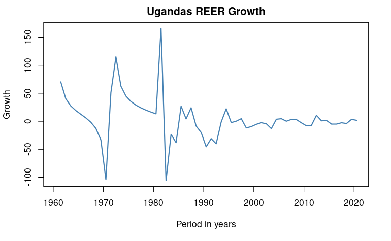

```r
plot(as.zoo(REER_Growth),
      col = "steelblue",
      lwd = 2,
      ylab = "Growth",
      xlab = "Period in years",
      main = "Ugandas REER Growth"
)
```

**First level of Analysis** At this level of analysis, the autocorrelation between the different series shall be established then provide the narrative for the results

- - GDP - FDI_Inflow - FDI_stock - NFA_Spread - REER
- - GDP Growth

```r
#the data set
# GDP

N <- length(GDP_Growth)
N

GDP_level <- as.numeric(GDP_Growth[-1])
GDP_lags <-as.numeric(GDP_Growth[-N])

#estimate model
GDP_mod <- lm(GDP_level ~ GDP_lags)
GDP_armod <- dynlm(ts(GDP_level) ~ L(ts(GDP_level)) + L(ts(GDP_level), 2) + L(ts(GDP_level), 3) + L(ts(GDP_level), 4) )

#robust summary
coeftest(GDP_armod, vcov. = sandwich)
coeftest(GDP_mod, vcov. = sandwich)
#AR(2)
summary(GDP_armod)$sigma
summary(GDP_armod)$r.squared
#AR(1) like ols
summary(GDP_mod)$sigma
summary(GDP_mod)$r.squared

# Calculate the ACF and PACF
acf(na.omit(GDP_Growth), lag.max = 20, plot= T)
pacf(na.omit(GDP_Growth),lag.max = 20, plot= T)

# Use BIC to determine the lags
BIC(dynlm(ts(GDP_level) ~ 1))

ssr <- sum(GDP_armod$residualsˆ2)
t <- length(GDP_armod$residuals)
npar <- length(GDP_armod$coef)
ssr
t
npar
AIC(GDP_armod)
AICs <- sapply(1:6,FUN=function(x)"AR"=AIC(dynlm(ts(GDP_level) ~ L(ts(GDP_level),1:x))))

# ADF test for unit root
summary(ur.df(GDP,
  type = "trend",
  lags = 2,
  selectlags = "Fixed"))
```

[output not shown]

- -FDI_inflow

```r
#the data sets
# FDI_inflow

N <- length(FDI_Growth)
N

FDI_inflow_level <- as.numeric(FDI_Growth[-1])
FDI_inflow_lags <-as.numeric(FDI_Growth[-N])

#estimate model
FDI_inflow_mod <- lm(FDI_inflow_level ~ FDI_inflow_lags)
FDI_inflow_armod <- dynlm(ts(FDI_inflow_level) ~ L(ts(FDI_inflow_level)) + L(ts(FDI_inflow_level), 2) + L(ts(FDI_inflow_level), 3) + L(ts(FDI_inflow_level), 4))

#robust summary
coeftest(FDI_inflow_armod, vcov. = sandwich)
coeftest(FDI_inflow_mod, vcov. = sandwich)
#AR(2)
summary(FDI_inflow_armod)$sigma
summary(FDI_inflow_armod)$r.squared
#AR(1) like ols
summary(FDI_inflow_mod)$sigma
summary(FDI_inflow_mod)$r.squared

# Calculate the ACF and PACF
acf(na.omit(FDI_Growth), lag.max = 20, plot= T)
pacf(na.omit(FDI_Growth),lag.max = 20, plot= T,main="FDI Inflow")

# Use BIC to determine the lags
BIC(dynlm(ts(FDI_inflow_level) ~ 1))

ssr <- sum(FDI_inflow_armod$residualsˆ2)
t <- length(FDI_inflow_armod$residuals)
npar <- length(FDI_inflow_armod$coef)
ssr
t
npar
AIC(FDI_inflow_armod)
AICs <- sapply(1:6,FUN=function(x)"AR"=AIC(dynlm(ts(FDI_inflow_level) ~ L(ts(FDI_inflow_level),1:x))))

# ADF test for unit root
summary(ur.df(FDI_inflow,
  type = "trend",
  lags = 2,
  selectlags = "Fixed"))
```

[output not shown]

- - FDI_stock

```r
#the data sets
# REER
# NFA_d
# GDP
# FDI_inflow
# FDI_Stock
N <- length(FDI_Stock_Growth)
N

FDI_stock_level <- as.numeric(FDI_Stock_Growth[-1])
FDI_stock_lags <-as.numeric(FDI_Stock_Growth[-N])

#estimate model
FDI_stock_mod <- lm(FDI_stock_level ~ FDI_stock_lags)
FDI_stock_armod <- dynlm(ts(FDI_stock_level) ~ L(ts(FDI_stock_level)) + L(ts(FDI_stock_level), 2) + L(ts(FDI_stock_level), 3) + L(ts(FDI_stock_level), 4))

#robust summary
coeftest(FDI_stock_armod, vcov. = sandwich)
coeftest(FDI_stock_mod, vcov. = sandwich)
#AR(2)
summary(FDI_stock_armod)$sigma
summary(FDI_stock_armod)$r.squared
#AR(1) like ols
summary(FDI_stock_mod)$sigma
summary(FDI_stock_mod)$r.squared

# Calculate the ACF and PACF
acf(na.omit(FDI_Stock_Growth), lag.max = 20, plot= T)
pacf(na.omit(FDI_Stock_Growth),lag.max = 20, plot= T)

# Use BIC to determine the lags
BIC(dynlm(ts(FDI_inflow_level) ~ 1))

ssr <- sum(FDI_stock_armod$residualsˆ2)
t <- length(FDI_stock_armod$residuals)
npar <- length(FDI_stock_armod$coef)
ssr
t
npar
AIC(FDI_stock_armod)
AICs <- sapply(1:6,FUN=function(x)"AR"=AIC(dynlm(ts(FDI_stock_level) ~ L(ts(FDI_stock_level),1:x))))

# ADF test for unit root
summary(ur.df(FDI_Stock,
  type = "trend",
  lags = 2,
  selectlags = "Fixed"))
```

[output not shown]

**NFA**

```r
#the data sets
# NFA_d

N <- length(NFA_Growth)
N
NFA_Growth

NFA_level <- as.numeric(NFA_Growth[-1])
NFA_lags <-as.numeric(NFA_Growth[-N])

#estimate model
NFA_mod <- lm(NFA_level ~ NFA_lags)
NFA_armod <- dynlm(ts(NFA_level) ~ L(ts(NFA_level)) + L(ts(NFA_level), 2) + L(ts(NFA_level), 3) + L(ts(NFA_level), 4))

#robust summary
coeftest(NFA_armod, vcov. = sandwich)
coeftest(NFA_mod, vcov. = sandwich)
#AR(2)
summary(NFA_armod)$sigma
summary(NFA_armod)$r.squared
#AR(1) like ols
summary(NFA_mod)$sigma
summary(NFA_mod)$r.squared

# Calculate the ACF and PACF
acf(na.omit(NFA_Growth), lag.max = 20, plot= T)
pacf(na.omit(NFA_Growth),lag.max = 20, plot= T)

# Use BIC to determine the lags
BIC(dynlm(ts(NFA_level) ~ 1))

ssr <- sum(NFA_armod$residualsˆ2)
t <- length(NFA_armod$residuals)
npar <- length(NFA_armod$coef)
ssr
t
npar
AIC(NFA_armod)
AICs <- sapply(1:6,FUN=function(x)"AR"=AIC(dynlm(ts(NFA_level) ~ L(ts(NFA_level),1:x))))

# ADF test for unit root
summary(ur.df(NFA_d,
  type = "trend",
  lags = 2,
  selectlags = "Fixed"))
```

[output not shown]

**REER**

```r
#the data sets
# REER

N <- length(REER_Growth)
N

REER_level <- as.numeric(REER_Growth[-1])
REER_lags <-as.numeric(REER_Growth[-N])

#estimate model
REER_mod <- lm(REER_level ~ REER_lags)
REER_armod <- dynlm(ts(REER_level) ~ L(ts(REER_level)) + L(ts(REER_level), 2) + L(ts(REER_level), 3) + L(ts(REER_level), 4))

#robust summary
coeftest(REER_armod, vcov. = sandwich)
coeftest(REER_mod, vcov. = sandwich)
#AR(2)
summary(REER_armod)$sigma
summary(REER_armod)$r.squared
#AR(1) like ols
summary(REER_mod)$sigma
summary(REER_mod)$r.squared

# Calculate the ACF and PACF
acf(na.omit(REER_Growth), lag.max = 20, plot= T)
pacf(na.omit(REER_Growth),lag.max = 20, plot= T)

# ADF test for unit root
summary(ur.df(REER,
  type = "trend",
  lags = 2,
  selectlags = "Fixed"))
```

[output not shown]

**Testing and modeling using the ADL and testing for Predictability of the Regressors** At this level of analysis I shall fit a general regression model with multiple regressors which is an extension of the classical ADL model but with multiple Predictors. The mode is as follows, It uses p lags of the dependent variable and **ql** lags of **l** additional predictors where **l = 1, . . ., k** then applying the **Granger’s Causality Tests** to a certain the predictive power the lags included in the model to predict the dependent variable Then Determine the Dynamic Causal Effects of the Regressors.

```r
 GDP_adl <- dynlm(ts(GDP_level) ~ L(ts(GDP_level)) + L(ts(FDI_stock_level)) +L(ts(FDI_stock_level),2) + L(ts(FDI_inflow_level)) +L(ts(FDI_inflow_level),2) + L(ts(NFA_level)) +L(ts(NFA_level),2)+ L(ts(REER_level)) + L(ts(REER_level),2))
coeftest(GDP_adl, vcov. = sandwich)

GDP_adl_1 <- dynlm(ts(GDP_level) ~ L(ts(GDP_level)) + L(ts(FDI_stock_level)) + L(ts(FDI_inflow_level)) + L(ts(NFA_level)) + L(ts(REER_level)))
coeftest(GDP_adl, vcov. = sandwich)

print("ADL with multiple Regressors model's sigma R^2")
summary(GDP_adl)$sigma
print("sigma for the lag 1 ADL")
summary(GDP_adl_1)$sigma
summary(GDP_adl)$r.squared
# contrast with the AR(4) model of GDP_Growth
print("AR(4) model's sigma R^2 ")
summary(GDP_armod)$sigma
summary(GDP_armod)$r.squared

#F-test on coefficients of term spread (Granger's Causality Tests) that uses the F-Test
linearHypothesis(GDP_adl,
c("L(ts(FDI_stock_level))=0","L(ts(FDI_stock_level), 2)=0", "L(ts(FDI_inflow_level))=0","L(ts(FDI_inflow_level), 2)=0", "L(ts(NFA_level))=0","L(ts(NFA_level), 2)=0", "L(ts(REER_level))=0","L(ts(REER_level), 2)=0"),
vcov. = sandwich)

linearHypothesis(GDP_adl,
c("L(ts(FDI_inflow_level))=0" ,"L(ts(FDI_inflow_level), 2)=0"),
vcov. = sandwich)
linearHypothesis(GDP_adl,
c("L(ts(FDI_stock_level))=0","L(ts(FDI_stock_level), 2)=0"),
vcov. = sandwich)

linearHypothesis(GDP_adl,
c("L(ts(NFA_level))=0","L(ts(NFA_level), 2)=0"),
vcov. = sandwich)

linearHypothesis(GDP_adl,
c("L(ts(REER_level))=0","L(ts(REER_level), 2)=0"),
vcov. = sandwich)
```

[output not shown]

Regressions with non-stationary series are spurious and analyses are not valid. For this work, we test if there is stationarity by applying the Augmented Dickey-Fuller (ADF). Visually examining the autocorrelation function (ACF) and partial autocorrelation function (PACF) combined patterns should reveal some important features at least inconclusively which should help to identify the orders of AR and MA parameters of the model

```r
GDP_arimax <- arima (GDP_Growth, order=c(1, 2, 2),
                xreg=NFA_Growth)
GDP_arimax
GDP_arimax$coef

GDP_arimax_inflow <- arima (GDP_Growth, order=c(1, 2, 2),
                xreg=FDI_inflow)
GDP_arimax_inflow
GDP_arimax_inflow$coef

GDP_arimax_stock <- arima (GDP_Growth, order=c(1, 2, 2),
                xreg=FDI_Stock_Growth)
GDP_arimax_stock
GDP_arimax_stock$coef

REER_arimax <- arima (GDP_Growth, order=c(1, 2, 2),
                xreg=REER_Growth)

REER_arimax
REER_arimax$coef

#values <- forecast(GDP_arimax, newxreg=NFA_Growth)
#values
```

[output not shown]